# filter-julia.tcl documentation

Detlef Groth, Caputh-Schwielowsee, Germany

May 24, 2023

filter-abc - filter-cmd - filter-dot - filter-emf - filter-eqn - filter-julia - filter-kroki - filter-mmd - filter-mtex - filter-pic/dpic - filter-pik  
filter-pipe - filter-puml - filter-rplot - filter-sqlite - filter-tcrd - filter-tcl - filter-tdot - filter-tsvg

Documentation: Pantcl filter documentation - Pantcl tutorial - Pantcl Readme - Pantcl Gui

## Name

*filter-julia.tcl* - Filter which can be used to execute Julia code within code chunks (slow!).

## Usage

The conversion of the Markdown documents via Pandoc should be done as follows:

```
pandoc input.md --filter pantcl.bin -s -o output.html
```

The file `filter-julia.tcl` is not used directly but sourced automatically by the `pantcl.bin` file. If code blocks with the `.julia` marker are found, the contents in the code block is processed via the julia interpreter, currently using pipes. Please note that Julia is slow at startup, plotting and pipe communication.

The following options can be given via code chunks or in the YAML header.

> - eval - should the code in the code block be evaluated, default: false (0)
> - echo - should the input code been shown, default: true
> - plotengine - the plot engine, default: pyplot
> - results - should the output of the command line application been shown, should be asis, show or hide, default: show
> - wait - the timeout (ms) after every code evaluation to wait for the pipe to read, try to decrease the time to get a speedup, increase of you observe output at wrong places, default: 100

To change the defaults the YAML header can be used. Here an example to change the to evaluate all Julia code chunks per default. Please note that you should write `eval: 1` and not(!) `eval: true`

```
 ----
 title: "filter-julia.tcl documentation"
 author: "Detlef Groth, University of Potsdam, Germany"
 date: 2023-05-24
 julia:
     eval: 1
     wait: 1000
 ----
```

## Examples

### Julia example

````
     ```{.julia eval=true}
     x=1;
     l = [1,2,3]

     for i in l
       println(i)
     end

     println(x+2);
     x=2
     ```
````

Here the output:

```julia
x=1;
l = [1,2,3]

for i in l
   println(i)
end

println(x+2);
x=2
```

```
julia>  x=1;
julia>  l = [1,2,3]
julia>
julia>  for i in l
julia>     println(i)
julia>  end
1
julia>
julia>  println(x+2);
julia>  x=2
3-element Vector{Int64}:
 1
 2
 3
1
2
3
3
2
```

Now let’s create an image try with PyPlot. Creating standard image plots with `using Plots` is much too slow!! Around 20 seconds!! Julia is probably a fast calculator, but startup and plotting is not … - chunk options `{.julia fig=true}`

```julia
x = range(0, 1, length=30)
y = x .^ 2
plot(x, y,linewidth=5,color="salmon")
```

```
julia>  x = range(0, 1, length=30)
julia>  y = x .^ 2
julia>  plot(x, y,linewidth=5,color="salmon")
PyObject <matplotlib.pyplot._IoffContext object at 0x7fd7ceac7820>
0.0:0.034482758620689655:1.0
30-element Vector{Float64}:
 0.0
 0.0011890606420927466
 0.0047562425683709865
 0.01070154577883472
 0.019024970273483946
 0.02972651605231867
 0.04280618311533888
 0.0582639714625446
 0.07609988109393578
 0.09631391200951249
 0.11890606420927469
 0.14387633769322233
 0.17122473246135553
 0.2009512485136742
 0.2330558858501784
 0.26753864447086806
 0.30439952437574314
 0.34363852556480373
 0.38525564803804996
 0.42925089179548154
 0.47562425683709875
 0.5243757431629014
 0.5755053507728893
 0.6290130796670631
 0.6848989298454221
 0.7431629013079666
 0.8038049940546969
 0.8668252080856124
 0.9322235434007136
 1.0
1-element Vector{PyCall.PyObject}:
 PyObject <matplotlib.lines.Line2D object at 0x7fd7c9c5c3a0>
```

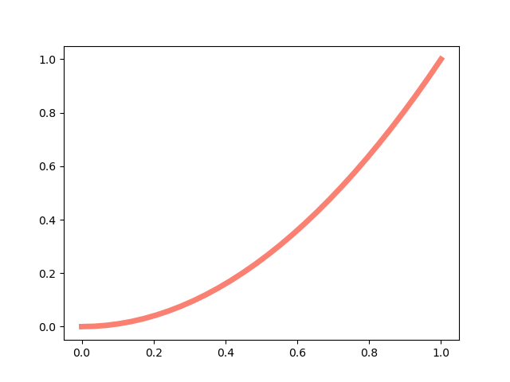

Alternatively you can use the cmd-filter - chunk options `{.cmd eval=true file=test.jl}`:

```
#!/usr/bin/env julia
println("Hello Julia World!")
```

```
Hello Julia World!
```

Here let’s create a plot - chunk options `{.cmd eval=true file=test-plot.jl}`:

```
#!/usr/bin/env julia
t1=time()
using Plots
x = range(0, 10, length=100)
y = sin.(x)
plot(x, y)
savefig("test-plot.png")
t2=time()
println("running time: ",round(t2-t1))
```

```
running time: 20.0
```

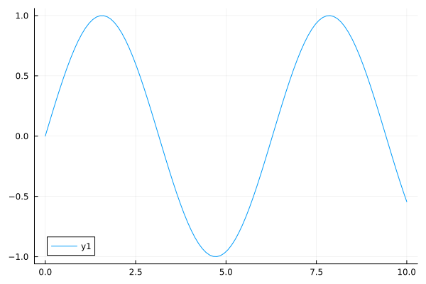

So startup and plotting in Julia is extremly slow.

Let’s compare this with R:

```
#!/usr/bin/env Rscript
t1=Sys.time()
x=seq(0,10,0.1)
y=sin(x)
png("test-plot-R.png",width=900,height=600)
plot(x,y,type="l", xlab="time", ylab="Sine wave",col="blue",lwd=2)
grid()
dev.off()
t2=Sys.time()
print(t2-t1)
```

```
null device
          1
Time difference of 0.08919764 secs
```

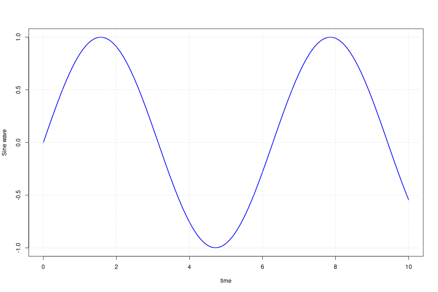

So R is much faster!

Debugging:

```
puts "time for document compilation: [expr {[clock seconds] - $t}]"
```

```
time for document compilation: 37
```

## TODO:

- terminal mode on/off

## See also:

- Pantcl Readme
- Tcl filter
- Rplot filter